# Biostatistics III in R

Code by Mark Clements

# Exercise 14. Non-collapsibility of proportional hazards models

We simulate for time-to-event data assuming *constant hazards* and then investigate whether we can estimate the underlying parameters. Note that the binary variable $X$ is essentially a coin toss and we have used a large variance for the normally distributed $U$.

You may have to install the required packages the first time you use them. You can install a package by `install.packages("package_of_interest")` for each package you require.

```r
library(biostat3)
library(rstpm2)
library(ggplot2)
```

The assumed causal diagram is reproduced below:

[figure not shown]

```r
set.seed(12345)
d <- local({
    n <- 1e4
    x <- rbinom(n, 1, 0.5)
    u <- rnorm(n, 0, 3)
    t <- rexp(n, exp(-5+x+u))
    c <- runif(n, 0, 10)
    y <- pmin(t, c)
    delta <- (t < c)
    data.frame(y,x,u,delta)
})
head(d)
```

```
##          y x          u delta
## 1 1.809348 1 -2.0774167 FALSE
## 2 1.251765 1  3.3740868  TRUE
## 3 2.078184 1  0.5236054 FALSE
## 4 3.528797 1 -5.9034201 FALSE
## 5 6.659236 0 -4.9328152 FALSE
## 6 5.366579 0 -0.3293542 FALSE
```

## (a) Fitting models with both $X$ and $U$

For constant hazards, we can fit (i) Poisson regression, (ii) Cox regression and (iii) flexible parametric survival models. With both covariates, these models are expected to estimate the parameters for $X$ and $U$, with values close to 1:

```r
summary(fit1 <- glm(delta~x+u+offset(log(y)),data=d,family=poisson))
```

```
##
## Call:
## glm(formula = delta ~ x + u + offset(log(y)), family = poisson,
##     data = d)
##
## Coefficients:
##             Estimate Std. Error z value Pr(>|z|)
## (Intercept) -4.97595    0.05344  -93.11   <2e-16 ***
## x            0.96027    0.04372   21.96   <2e-16 ***
## u            0.99087    0.01091   90.78   <2e-16 ***
## ---
## Signif. codes:  0 '***' 0.001 '**' 0.01 '*' 0.05 '.' 0.1 ' ' 1
##
## (Dispersion parameter for poisson family taken to be 1)
##
##     Null deviance: 14687.0  on 9999  degrees of freedom
## Residual deviance:  5811.2  on 9997  degrees of freedom
## AIC: 10257
##
## Number of Fisher Scoring iterations: 7
```

```r
summary(fit2 <- coxph(Surv(y,delta)~x+u,data=d))
```

```
## Call:
## coxph(formula = Surv(y, delta) ~ x + u, data = d)
##
##   n= 10000, number of events= 2220
##
##      coef exp(coef) se(coef)     z Pr(>|z|)
## x 0.96227   2.61764  0.04490 21.43   <2e-16 ***
## u 0.99034   2.69215  0.01461 67.81   <2e-16 ***
## ---
## Signif. codes:  0 '***' 0.001 '**' 0.01 '*' 0.05 '.' 0.1 ' ' 1
##
##   exp(coef) exp(-coef) lower .95 upper .95
## x     2.618     0.3820     2.397     2.858
## u     2.692     0.3714     2.616     2.770
##
## Concordance= 0.922  (se = 0.002 )
## Likelihood ratio test= 7448  on 2 df,   p=<2e-16
## Wald test            = 4629  on 2 df,   p=<2e-16
## Score (logrank) test = 5611  on 2 df,   p=<2e-16
```

```r
summary(fit3 <- stpm2(Surv(y,delta)~x+u,data=d,df=4))
```

```
## Maximum likelihood estimation
##
## Call:
## stpm2(formula = Surv(y, delta) ~ x + u, data = d, df = 4)
##
## Coefficients:
##                        Estimate Std. Error z value     Pr(z)
## (Intercept)          -14.565979   0.516079 -28.224 < 2.2e-16 ***
## x                      0.960750   0.044878  21.408 < 2.2e-16 ***
## u                      0.990848   0.014600  67.865 < 2.2e-16 ***
## nsx(log(y), df = 4)1   9.424531   0.494145  19.072 < 2.2e-16 ***
## nsx(log(y), df = 4)2   8.786272   0.328904  26.714 < 2.2e-16 ***
## nsx(log(y), df = 4)3  16.534497   1.013387  16.316 < 2.2e-16 ***
## nsx(log(y), df = 4)4   8.562140   0.206188  41.526 < 2.2e-16 ***
## ---
## Signif. codes:  0 '***' 0.001 '**' 0.01 '*' 0.05 '.' 0.1 ' ' 1
##
## -2 log L: 8520.997
```

```r
## summary table for the coefficients for X
rbind(Poisson=coef(summary(fit1))["x",c("Estimate","Std. Error")],
      Cox=coef(summary(fit2))["x",c("coef","se(coef)")],
      Stpm2=coef(summary(fit3))["x",c("Estimate","Std. Error")])
```

```
##          Estimate Std. Error
## Poisson 0.9602659 0.04372345
## Cox     0.9622728 0.04490412
## Stpm2   0.9607498 0.04487831
```

If we fit a time-varying hazard ratio for $X$, we see that the hazard ratio looks reasonably constant.

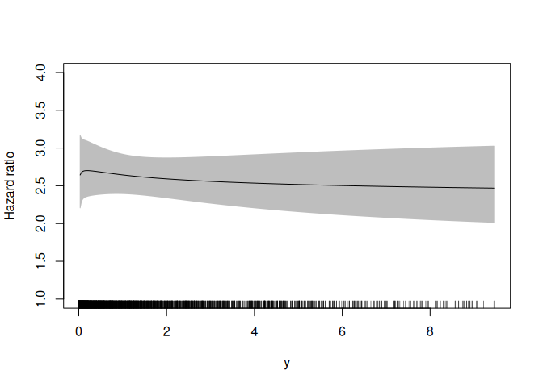

```r
fit <- stpm2(Surv(y,delta)~x+u,data=d,df=4, tvc=list(x=2)) # slow
plot(fit, type="hr", newdata=data.frame(x=0,u=0), var="x", ylim=c(1,4))
```

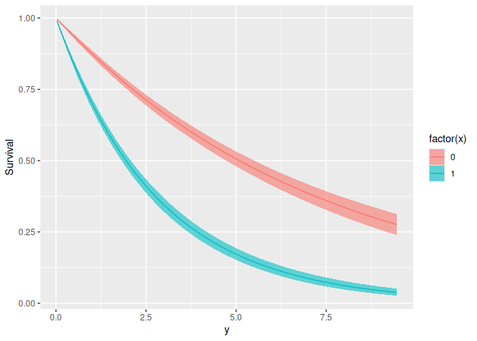

```r
predict(fit, type="surv", newdata=data.frame(x=0:1,u=3), grid=TRUE, full=TRUE,
        se.fit=TRUE) |>
    ggplot(aes(x=y,y=Estimate,fill=factor(x),ymin=lower,ymax=upper)) +
    ylab("Survival") +
    geom_ribbon(alpha=0.6) +
    geom_line(aes(colour=factor(x)))
```

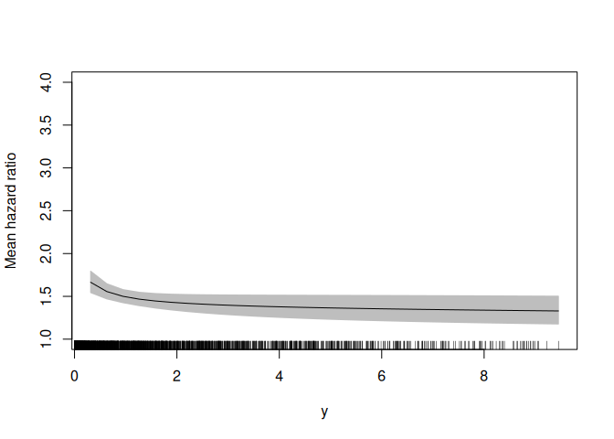

```r
## standardisation: slow:(
plot(fit, type="meanhr", newdata=transform(d,x=0), var="x", seqLength=31, ylim=c(1,4))
```

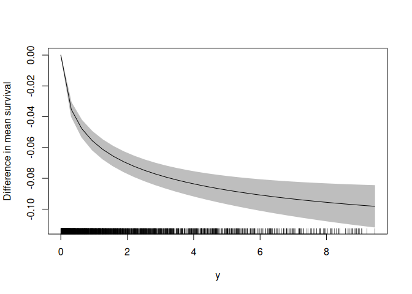

```r
plot(fit, type="meansurvdiff", newdata=transform(d,x=0), var="x", seqLength=31)
```

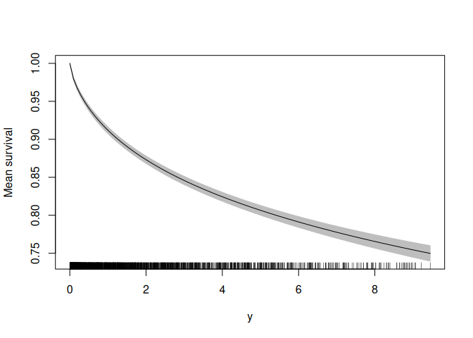

```r
plot(fit, type="meansurv", newdata=transform(d,x=0), seqLength=101)
```

## (b) Fitting models with only $X$

We now model by excluding the variable $U$. This variable could be excluded when it is not measured or perhaps when the variable is not considered to be a confounding variable – from the causal diagram, the two variables $X$ and $U$ are not correlated and are only connected through the time variable $T$.

```r
summary(fit1 <- glm(delta~x+offset(log(y)),data=d,family=poisson))
```

```
##
## Call:
## glm(formula = delta ~ x + offset(log(y)), family = poisson, data = d)
##
## Coefficients:
##             Estimate Std. Error z value Pr(>|z|)
## (Intercept) -3.19636    0.03377  -94.66   <2e-16 ***
## x            0.51289    0.04341   11.81   <2e-16 ***
## ---
## Signif. codes:  0 '***' 0.001 '**' 0.01 '*' 0.05 '.' 0.1 ' ' 1
##
## (Dispersion parameter for poisson family taken to be 1)
##
##     Null deviance: 14687  on 9999  degrees of freedom
## Residual deviance: 14544  on 9998  degrees of freedom
## AIC: 18988
##
## Number of Fisher Scoring iterations: 7
```

```r
summary(fit2 <- coxph(Surv(y,delta)~x,data=d))
```

```
## Call:
## coxph(formula = Surv(y, delta) ~ x, data = d)
##
##   n= 10000, number of events= 2220
##
##      coef exp(coef) se(coef)     z Pr(>|z|)
## x 0.48511   1.62436  0.04342 11.17   <2e-16 ***
## ---
## Signif. codes:  0 '***' 0.001 '**' 0.01 '*' 0.05 '.' 0.1 ' ' 1
##
##   exp(coef) exp(-coef) lower .95 upper .95
## x     1.624     0.6156     1.492     1.769
##
## Concordance= 0.565  (se = 0.005 )
## Likelihood ratio test= 127.9  on 1 df,   p=<2e-16
## Wald test            = 124.8  on 1 df,   p=<2e-16
## Score (logrank) test = 127.3  on 1 df,   p=<2e-16
```

```r
summary(fit3 <- stpm2(Surv(y,delta)~x,data=d,df=4))
```

```
## Maximum likelihood estimation
##
## Call:
## stpm2(formula = Surv(y, delta) ~ x, data = d, df = 4)
##
## Coefficients:
##                       Estimate Std. Error z value     Pr(z)
## (Intercept)          -9.883577   0.473288 -20.883 < 2.2e-16 ***
## x                     0.485236   0.043423  11.175 < 2.2e-16 ***
## nsx(log(y), df = 4)1  7.458585   0.467806  15.944 < 2.2e-16 ***
## nsx(log(y), df = 4)2  6.323162   0.310308  20.377 < 2.2e-16 ***
## nsx(log(y), df = 4)3 13.212493   0.930874  14.194 < 2.2e-16 ***
## nsx(log(y), df = 4)4  5.541993   0.192044  28.858 < 2.2e-16 ***
## ---
## Signif. codes:  0 '***' 0.001 '**' 0.01 '*' 0.05 '.' 0.1 ' ' 1
##
## -2 log L: 15844.98
```

```r
## summary table for the coefficients for X
rbind(Poisson=coef(summary(fit1))["x",c("Estimate","Std. Error")],
      Cox=coef(summary(fit2))["x",c("coef","se(coef)")],
      Stpm2=coef(summary(fit3))["x",c("Estimate","Std. Error")])
```

```
##          Estimate Std. Error
## Poisson 0.5128869 0.04341441
## Cox     0.4851147 0.04342341
## Stpm2   0.4852363 0.04342328
```

We clearly see that the estimate for $X$ is different in the models without $U$. If we now allow the the hazard ratio to vary by time:

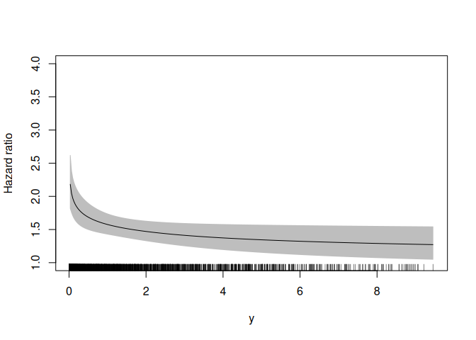

```r
fit <- stpm2(Surv(y,delta)~x,data=d,df=4, tvc=list(x=2))
plot(fit, type="hr", newdata=data.frame(x=0), var="x", ylim=c(1,4))
```

We see that the hazard ratio is clearly time-varying, starting at an initial value at time = 0 of close to exp(1), but then declining rapidly. As discussed in class, this is an example of *unmeasured heterogeneity*, which is a normal *random effect* or, in this context, a log-normal *frailty*. Initially, there is no selection in the at-risk population, and the estimated marginal hazard ratio from the model without $U$ is similar to the conditional hazrd ratio from the model that adjusts for $U$. However, at later times, the at-risk population has been selected for those with a smaller frailty (because they were less likely to have had the event), and for a log-normal frailty the marginal hazard ratio is attenuated towards 1.

Let us stress that *$U$ is not a confounder*. The issue is that fitting proportional hazards models with unmodelled heterogeneity for variables that are not confounders can lead to time-varying hazard ratios – and marginal estimates that do not have a causal interpretation.

## (c) Rarer outcomes

We now simulate for rarer outcomes by changing the censoring distribution.

```r
set.seed(12345)
d <- local({
    n <- 1e4*10 # CHANGED N
    x <- rbinom(n, 1, 0.5)
    u <- rnorm(n, 0, 3)
    t <- rexp(n, exp(-5+x+u))
    c <- runif(n, 0, 10/1000) # CHANGED FROM 10 TO 0.01
    y <- pmin(t, c)
    delta <- (t < c)
    data.frame(y,x,u,delta)
})
```

```r
summary(fit1 <- glm(delta~x+offset(log(y)),data=d,family=poisson))

summary(fit2 <- coxph(Surv(y,delta)~x,data=d))

summary(fit3 <- stpm2(Surv(y,delta)~x,data=d,df=4))
```

```r
## summary table for the coefficients for X
rbind(Poisson=coef(summary(fit1))["x",c("Estimate","Std. Error")],
      Cox=coef(summary(fit2))["x",c("coef","se(coef)")],
      Stpm2=coef(summary(fit3))["x",c("Estimate","Std. Error")])
```

```
##         Estimate Std. Error
## Poisson 1.081150  0.1212037
## Cox     1.081513  0.1212136
## Stpm2   1.081399  0.1212136
```

For rarer outcomes, the marginal estimates that do not model for $U$ are closer to the conditional estimates that have modelled for $U$.

## (d) Less heterogeneity

We now simulate for less heterogeneity by changing the reducing the standard deviation for the random effect $U$ from 3 to 1.

```r
set.seed(12345)
d <- local( {
    n <- 1e4
    x <- rbinom(n, 1, 0.5)
    u <- rnorm(n, 0, 1) # CHANGED SD FROM 3 TO 1
    t <- rexp(n, exp(-5+x+u))
    c <- runif(n, 0, 10)
    y <- pmin(t, c)
    delta <- (t < c)
    data.frame(y,x,u,delta)
})
```

```r
summary(fit1 <- glm(delta~x+offset(log(y)),data=d,family=poisson))

summary(fit2 <- coxph(Surv(y,delta)~x,data=d))

summary(fit3 <- stpm2(Surv(y,delta)~x,data=d,df=4))
```

```r
## summary table for the coefficients for X
rbind(Poisson=coef(summary(fit1))["x",c("Estimate","Std. Error")],
      Cox=coef(summary(fit2))["x",c("coef","se(coef)")],
      Stpm2=coef(summary(fit3))["x",c("Estimate","Std. Error")])
```

```
##          Estimate Std. Error
## Poisson 0.9498227 0.07583196
## Cox     0.9444216 0.07584759
## Stpm2   0.9441747 0.07584672
```

The marginal estimates are now much closer to the conditional estimates. For little or no heterogeneity, the marginal and conditional estimates would be very similar.

## (e) Accelerated failure time models

We re-run the baseline simulations:

```r
set.seed(12345)
d <- local({
    n <- 1e4
    x <- rbinom(n, 1, 0.5)
    u <- rnorm(n, 0, 3)
    t <- rexp(n, exp(-5+x+u))
    c <- runif(n, 0, 10)
    y <- pmin(t, c)
    delta <- (t < c)
    data.frame(y,x,u,delta)
})
head(d)
```

The accelerated failure time models have the form $S(t|x,u)=S_0(t/\exp( \beta_1 x + \beta_2 u))$, where the function $S_0(t)$ is expressed in terms of splines. For an exponential distribution, the hazard ratio is equal to the inverse of the ratio of the means — so we expect values of $-1$ for $x$ and $u$.

```r
fit <- aft(Surv(y,delta)~x+u,data=d,df=4)
summary(fit)
```

```
## Maximum likelihood estimation
##
## Call:
## bbmle::mle2(minuslogl = negll, start = coef, eval.only = TRUE,
##     vecpar = TRUE, gr = gradient, control = control)
##
## Coefficients:
##                                        Estimate Std. Error  z value     Pr(z)
## x                                     -0.962300   0.044098 -21.8218 < 2.2e-16
## u                                     -0.991064   0.012670 -78.2240 < 2.2e-16
## nsx(logtstar, df, intercept = TRUE)1  -3.541448   1.262247  -2.8057  0.005021
## nsx(logtstar, df, intercept = TRUE)2   1.847778   1.122168   1.6466  0.099637
## nsx(logtstar, df, intercept = TRUE)3 -20.886221   3.220093  -6.4862 8.802e-11
## nsx(logtstar, df, intercept = TRUE)4   8.702543   2.087292   4.1693 3.055e-05
##
## x                                    ***
## u                                    ***
## nsx(logtstar, df, intercept = TRUE)1 **
## nsx(logtstar, df, intercept = TRUE)2 .
## nsx(logtstar, df, intercept = TRUE)3 ***
## nsx(logtstar, df, intercept = TRUE)4 ***
## ---
## Signif. codes:  0 '***' 0.001 '**' 0.01 '*' 0.05 '.' 0.1 ' ' 1
##
## -2 log L: 8520.726
```

```r
fit <- aft(Surv(y,delta)~x,data=d,df=4)
summary(fit)
```

```
## Maximum likelihood estimation
##
## Call:
## bbmle::mle2(minuslogl = negll, start = coef, eval.only = TRUE,
##     vecpar = TRUE, gr = gradient, control = control)
##
## Coefficients:
##                                        Estimate Std. Error  z value     Pr(z)
## x                                     -1.036624   0.091058 -11.3842 < 2.2e-16
## nsx(logtstar, df, intercept = TRUE)1  -1.712803   0.202523  -8.4573 < 2.2e-16
## nsx(logtstar, df, intercept = TRUE)2   1.744380   0.158298  11.0196 < 2.2e-16
## nsx(logtstar, df, intercept = TRUE)3 -12.163961   0.465543 -26.1286 < 2.2e-16
## nsx(logtstar, df, intercept = TRUE)4   5.648685   0.296200  19.0705 < 2.2e-16
##
## x                                    ***
## nsx(logtstar, df, intercept = TRUE)1 ***
## nsx(logtstar, df, intercept = TRUE)2 ***
## nsx(logtstar, df, intercept = TRUE)3 ***
## nsx(logtstar, df, intercept = TRUE)4 ***
## ---
## Signif. codes:  0 '***' 0.001 '**' 0.01 '*' 0.05 '.' 0.1 ' ' 1
##
## -2 log L: 15835.68
```

We see that the model with both $x$ and $u$ estimates values are very close to $-1$ — which is as expected. Importantly, the model with only $x$ also estimates a value close to $-1$, which shows that the acclerated failure time models are robust to omitted covariates. The standard error for $x$ was smaller in the model with both $x$ and $u$ compared with that for the model with only $x$.